# 4-ый этап индивидуального проекта

Операционные системы

Верниковская Е. А., НПИбд-01-23

Российский университет дружбы народов, Москва, Россия

21 апреля 2024

# Вводная часть

## Цель работы

Добавить к сайту ссылки на научные и библиометрические ресурсы.

## Задание

1. Зарегистрироваться на соответствующих ресурсах и разместить на них ссылки на сайте:
- eLibrary : https://elibrary.ru/;
- Google Scholar : https://scholar.google.com/;
- ORCID : https://orcid.org/;
- Mendeley : https://www.mendeley.com/;
- ResearchGate : https://www.researchgate.net/;
- Academia.edu : https://www.academia.edu/;
- arXiv : https://arxiv.org/;
- github : https://github.com/.

## Задание

2. Сделать пост по прошедшей неделе.
3. Добавить пост на тему по выбору:
- Оформление отчёта.
- Создание презентаций.
- Работа с библиографией.

# Выполнение 4-ого этапа индивидуального проекта

## Регистрация на научных и библиометрических ресурсах

Регистрируемся на eLibrary (рис. 1), (рис. 2)

## Регистрация на научных и библиометрических ресурсах

[figure not shown]

Регистрация на eLibrary

## Регистрация на научных и библиометрических ресурсах

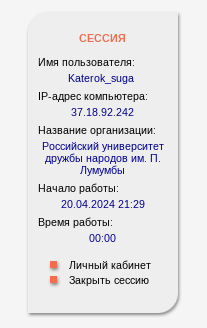

Мой профиль на eLibrary

## Регистрация на научных и библиометрических ресурсах

Регистрируемся на ORCID (рис. 3), (рис. 4)

## Регистрация на научных и библиометрических ресурсах

[figure not shown]

Регистрация на ORCID

## Регистрация на научных и библиометрических ресурсах

[figure not shown]

Мой профиль на ORCID

## Регистрация на научных и библиометрических ресурсах

Регистрируемся на Mendeley (рис. 5), (рис. 6)

## Регистрация на научных и библиометрических ресурсах

[figure not shown]

Регистрация на Mendeley

## Регистрация на научных и библиометрических ресурсах

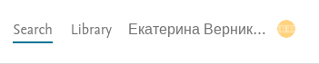

Мой профиль на Mendeley

## Регистрация на научных и библиометрических ресурсах

Регистрируемся на ResearchGate (рис. 7), (рис. 8)

## Регистрация на научных и библиометрических ресурсах

[figure not shown]

Регистрация на ResearchGate

## Регистрация на научных и библиометрических ресурсах

[figure not shown]

Мой профиль на ResearchGate

## Регистрация на научных и библиометрических ресурсах

Регистрируемся на Academia.edu (рис. 9), (рис. 10)

## Регистрация на научных и библиометрических ресурсах

[figure not shown]

Регистрация на Academia.edu

## Регистрация на научных и библиометрических ресурсах

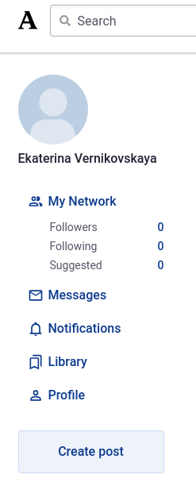

Мой профиль на Academia.edu

## Регистрация на научных и библиометрических ресурсах

Регистрируемся на arXiv (рис. 11), (рис. 12)

## Регистрация на научных и библиометрических ресурсах

[figure not shown]

Регистрация на arXiv

## Регистрация на научных и библиометрических ресурсах

[figure not shown]

Мой профиль на arXiv

## Регистрация на научных и библиометрических ресурсах

На Google Scholar и github я уже была зарегестрирована (рис. 13), (рис. 14])

## Регистрация на научных и библиометрических ресурсах

[figure not shown]

Мой профиль на Google Scholar

## Регистрация на научных и библиометрических ресурсах

[figure not shown]

Мой профиль на github

## Добавление ссылок на научные и библиометрические ресурсы

Заходим в каталог ~/work/blog. Далее запускаем исполняемый файл hugo, с помощью команды *~/bin/hugo server* и переходим на наш локальный сайт (рис. 15)

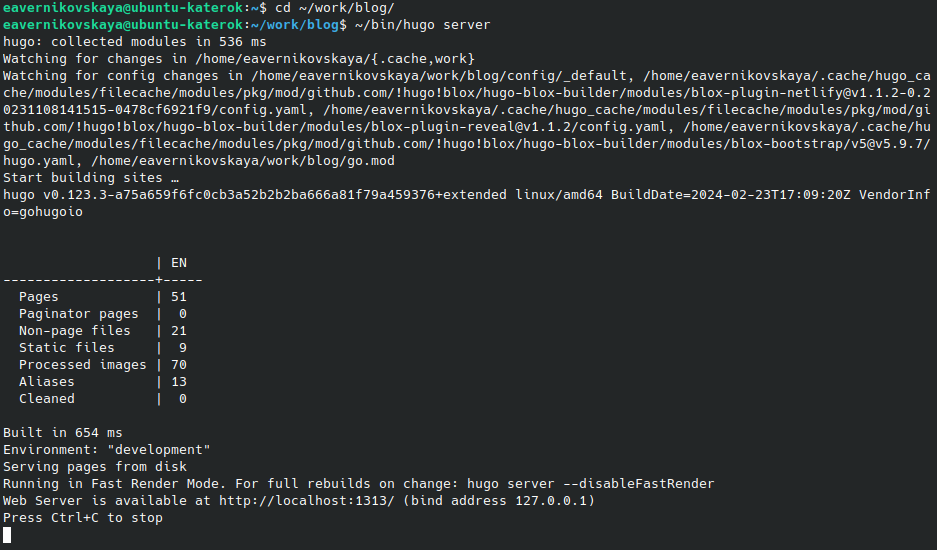

Запуск исполняемого файла

## Добавление ссылок на научные и библиометрические ресурсы

Потом переходим в каталог ~/work/blog/content/authors/admin и редактируем файл _index.md. Добавляем ссылок на научные и библиометрические ресурсы, где мы ранее зарегестрировались (рис. 16)

## Добавление ссылок на научные и библиометрические ресурсы

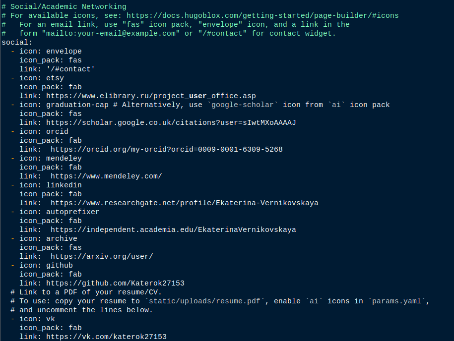

Редактирование файла _index.md

## Размещение постов на сайте

Переходим в каталог ~/work/blog/content/post и создаём две папки (я назвала их *post_5* и *post_6*), где будут хранится материалы постов (рис. 17), (рис. 18), (рис. 19)

[figure not shown]

Папки с материалама постов

## Размещение постов на сайте

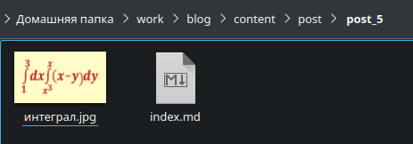

Материалы для поста о прошедшей неделе

## Размещение постов на сайте

[figure not shown]

Материалы для поста по выбранной теме

## Размещение постов на сайте

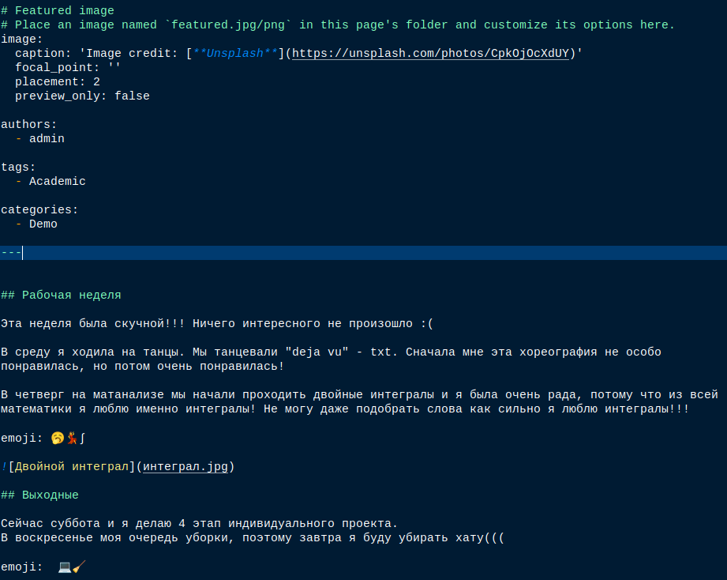

Файл поста по прошедшей неделе

## Размещение постов на сайте

Далее редактируем другой файл index.md в папке post_6. Я выбрала тему “Создание презентаций.” (рис. 21)

## Размещение постов на сайте

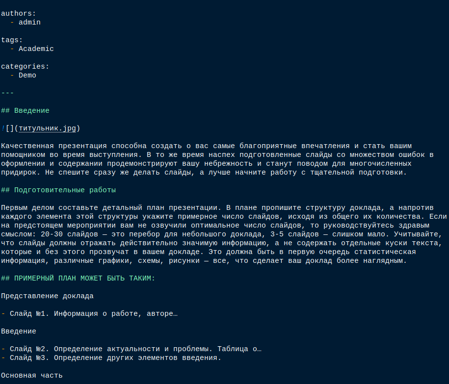

Файл поста по выборанной теме

## Сборка сайта

Собираем наш сайт выполнив в каталоге ~/work/blog команду *~/bin/hugo* (рис. 22)

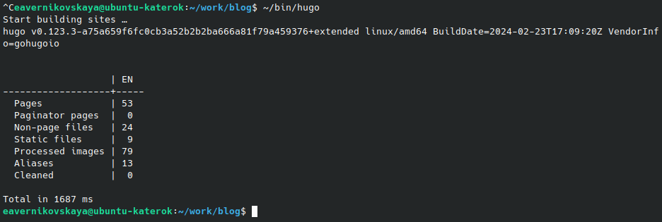

Сборка сайта

## Сборка сайта

Далее сохраняем изменения и отправляем их на git (рис. 23)

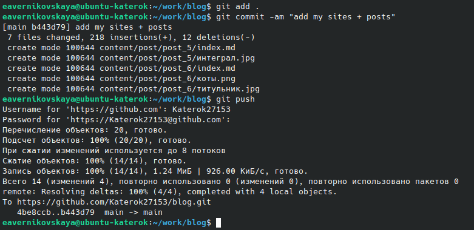

Сохранение и отправка изменений на git

## Сборка сайта

Далее переходим в каталог ~/work/blog/public и также сохраняем изменения и выкладываем их на git (рис. 24), (рис. 25)

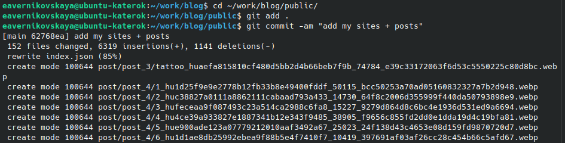

Сохранение и коммит изменений

## Сборка сайта

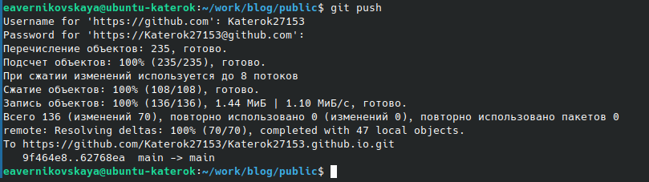

Отправка изменений на git

## Сборка сайта

Далее переходим на наш сайт (не на локальный!) по ссылке katerok27153.github.io и видим что всё получилось (рис. 26), (рис. 27), (рис. 28)

[figure not shown]

Ссылки на библиометрические ресурсы

## Сборка сайта

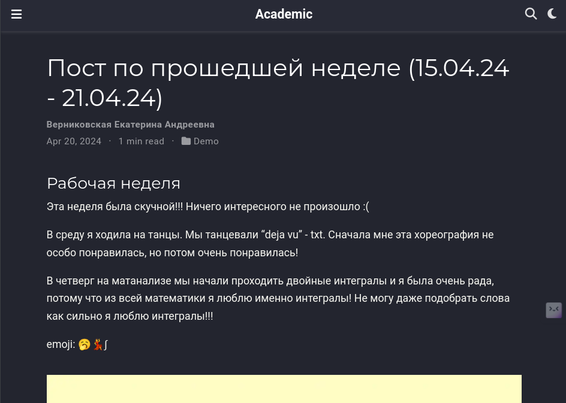

Пост по прошедшей недели

## Сборка сайта

[figure not shown]

Пост на тему “Создание презентаций.”

# Подведение итогов

## Выводы

В ходе выполнения 4-ого этапа индивидуального проекта мы научились регистрироваться на научных и библиометрических ресурсах и добавлять ссылки на наш сайт.

## Список литературы

1. Мой сайт [Электронный ресурс] URL: https://katerok27153.github.io/
2. Этапы реализации проекта [Электронный ресурс] URL: https://esystem.rudn.ru/mod/page/view.php?id=1098920
3. Официальная библиотека иконок [Электронный ресурс] URL: https://fontawesome.ru/all-icons/
4. Очень много ссылок на библиометрические ресурсы